# Visualiser les données

Xavier La Rochelle

2023-03-31

*Important :* Ce guide assume que vous savez comment :

1. Rédiger un script RMarkdown
2. Installer et activer des packages
3. Importer une base de données
4. Préparer des données

Dans ce guide, nous apprendrons à créer des graphiques pour visualiser des données.

## 0.1 Nouveau fichier de données!

Les données que nous utiliserons à titre d’exemple dans ce guide (`data_visualisation.csv`) ne seront pas les mêmes que celles des guides précédents (`RCC-5323-F-2020-SM_F1.csv`). J’aurais préféré garder le même fichier de données pour tous les guides mais celui que j’utilisais jusqu’à date ne comprenait qu’une seule variable continue. Pour pouvoir mettre en relation deux variables continues, je suis aller chercher un nouveau fichier de données (`data_visualisation.csv`).

### 0.1.1 Importer et préparer les données

Pour vous évitez de tout re-coder, j’ai pris le temps d’écrire la syntaxe nécessaire pour importer et préparer les données. Pour suivre les exemples dans ce guide, vous devrez donc :

1. avoir téléchargé le fichier `data_visualisation.csv` sur Studium
2. noter le `"folder path"`
3. utiliser la syntaxe suivante pour préparer les données dans R :

```r
# Packages
library(readr)
library(tibble)
library(ggplot2)
library(frq)

# Importer les données (data_visualisation.csv)
donnees_brutes <- read_csv("folder path")

# Préparer les données
df <- as_tibble(data.frame(id = 1:nrow(donnees_brutes)))
df$age <- donnees_brutes$Age
df$genre <- factor(donnees_brutes$Genre,
                   levels = c(1,2),
                   labels = c("Homme", "Femme"))
df$emotionPositive <- donnees_brutes$PANAS_Pos_Pre
df$symptomesDepressifs <- donnees_brutes$CESD_PreTotal
```

*Note: N’oubliez pas de changer le folder path!*

Voici à quoi devrait ressembler votre banque de données après l’étape de préparation :

```r
df
```

```
## # A tibble: 100 × 5
##       id   age genre emotionPositive symptomesDepressifs
##    <int> <dbl> <fct>           <dbl>               <dbl>
##  1     1    22 Femme              27                   9
##  2     2    20 Femme              27                   7
##  3     3    21 Femme              20                   1
##  4     4    21 Femme              26                  11
##  5     5    24 Femme              23                  23
##  6     6    24 Femme              21                   5
##  7     7    23 Femme              24                  10
##  8     8    19 Femme              29                   8
##  9     9    22 Homme              27                   4
## 10    10    19 Femme              41                   2
## # … with 90 more rows
```

### 0.1.2 Description des variables

Cette nouvelle banque de données ne vient pas d’Odesi donc elle n’est pas accompagnée d’un fichier de documentation. Voici tout de même une brève description des variables qu’elle contient :

#### Âge

**Type**: continue (de rapport)

**Description**: Âge de l’observation.

```r
descriptives(df, age)
```

```
##
##  DESCRIPTIVES
##
##  Descriptives
##  ──────────────────────────────────
##                          age
##  ──────────────────────────────────
##    N                          100
##    Missing                      0
##    Mean                  22.81000
##    Median                22.00000
##    Standard deviation    3.362584
##    Minimum               19.00000
##    Maximum               34.00000
##  ──────────────────────────────────
```

#### Genre

**Type**: catégorielle (nominale)

**Description**: Genre de l’observation.

```r
frq(df$genre)
```

```
## x <categorical>
## # total N=100 valid N=100 mean=1.73 sd=0.45
##
## Value |  N | Raw % | Valid % | Cum. %
## -------------------------------------
## Homme | 27 |    27 |      27 |     27
## Femme | 73 |    73 |      73 |    100
## <NA>  |  0 |     0 |    <NA> |   <NA>
```

#### Émotions positives

**Type**: continue (de rapport)

**Description**: Score totale d’émotions positives sur l’échelle [*Positive and Negative Affect Schedule*](https://ogg.osu.edu/media/documents/MB%20Stream/PANAS.pdf) (PANAS).

```r
descriptives(df, emotionPositive)
```

```
##
##  DESCRIPTIVES
##
##  Descriptives
##  ─────────────────────────────────────────
##                          emotionPositive
##  ─────────────────────────────────────────
##    N                                 100
##    Missing                             0
##    Mean                         27.44000
##    Median                       27.00000
##    Standard deviation           7.151068
##    Minimum                      13.00000
##    Maximum                      48.00000
##  ─────────────────────────────────────────
```

#### Symptômes dépressifs

**Type**: continue (de rapport)

**Description**: score total sur l’échelle [*Center for Epidemiologic Studies Depression Scale*](http://www.chcr.brown.edu/pcoc/cesdscale.pdf) (CES-D).

```r
descriptives(df, symptomesDepressifs)
```

```
##
##  DESCRIPTIVES
##
##  Descriptives
##  ─────────────────────────────────────────────
##                          symptomesDepressifs
##  ─────────────────────────────────────────────
##    N                                     100
##    Missing                                 0
##    Mean                             8.120000
##    Median                           8.000000
##    Standard deviation               5.650208
##    Minimum                          0.000000
##    Maximum                          25.00000
##  ─────────────────────────────────────────────
```

# 1 Le package `ggplot2`

Nous apprendrons à créer des graphiques avec le package `ggplot2` :

```r
library(ggplot2)
```

`ggplot2` est un package R populaire pour la production de graphiques. La syntaxe de ce package a été développée à partir du livre [*The Grammar of Graphics* (Wilkinson, 2005)](https://www.amazon.com/Grammar-Graphics-Statistics-Computing/dp/0387245448/ref=as_li_ss_tl). `ggplot2` utilise une syntaxe relativement simple et élégante pour permettre à l’utilisateur de créer des visualisations complexes à partir de données en utilisant une approche de composition de couches. offre une grande flexibilité pour personnaliser les aspects visuels des graphiques, tels que les couleurs, les légendes, les étiquettes et les thèmes. Dans ce guide, j’explique simplement quelques éléments essentiels de la « grammaire » de `ggplot2` mais, si la recherche vous intéresse, je vous encourage fortement à expérimenter avec ce package.

## 1.1 Les bases de `ggplot2`

Voici le « squelette » de syntaxe que je vous recommande d’utiliser lorsque vous créez des graphiques avec `ggplot2` :

```r
ggplot(df, aes()) +
  geom_() +
  labs(x = "", y = "") +
  theme_classic()
```

Comme mentionner précédemment, `ggplot2` utilise le concept de « couche » pour distinguer les différents éléments d’un graphique. Chaque couche est séparée par l’opérateur `+`, ce qui rend la syntaxe de `ggplot2` particulièrement facile à lire.

### 1.1.1 Première couche

La première couche utilise la fonction `ggplot()`, qui sert à définir les données que vous souhaitez utiliser dans votre graphique. Dans le premier argument de cette fonction, vous devez fournir la banque de données contenant vos variables. Le second argument (`aes()`) vous permet de déclarer vos variables. Par exemple, :

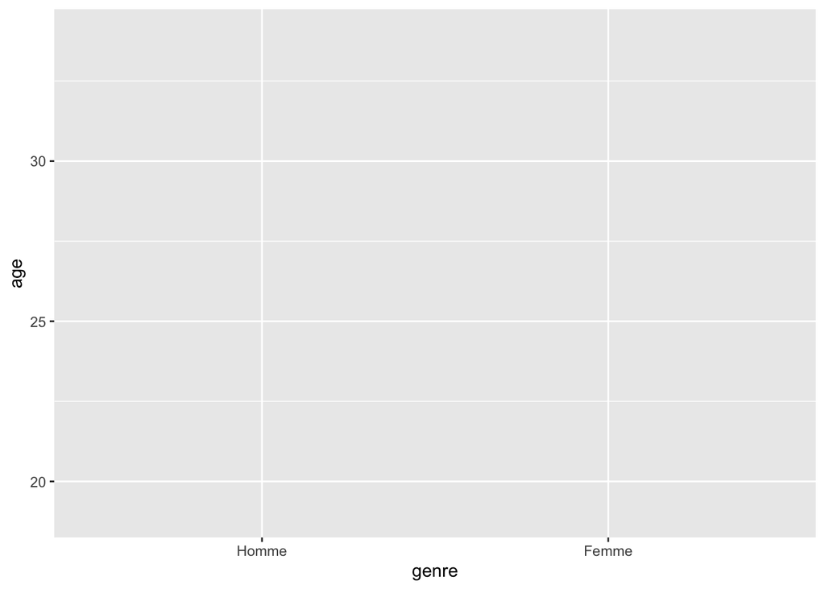

```r
ggplot(df, aes(x = genre, y = age))
```

Comme vous pouvez le constater, cette syntaxe permet de générer la base d’un graphique où la variable `genre` est assignée à l’axe des X et la variable `age` est assignée à l’axe des Y. Notez que `ggplot2` ajuste automatiquement l’affichage des échelles de mesure selon le format de vos variables, d’où l’importance d’assigner le bon format à vos variables (discrète = `factor` et continue = `numeric`) durant l’étape de préparation des données.

### 1.1.2 Les `Geoms`

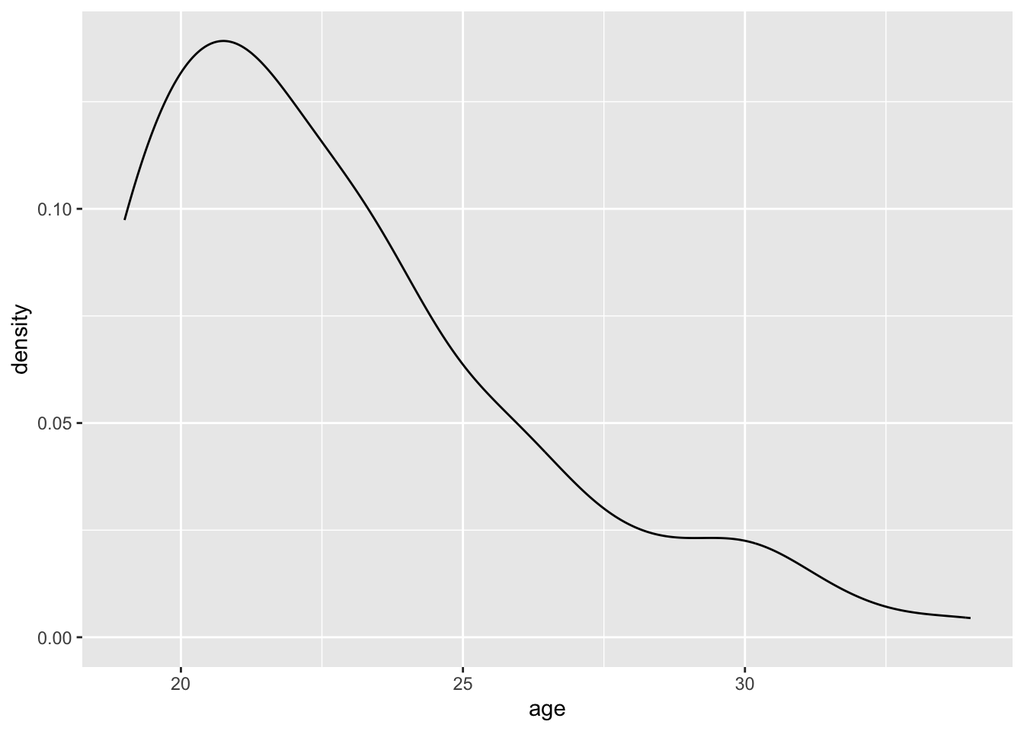

```r
ggplot(df, aes(x = age)) +
  geom_density()
```

### 1.1.3 Éléments esthétiques

Les deux dernières couches du modèle que j’ai fourni à la section 1.1 servent uniquement à contrôler l’apparence de votre graphique.

La troisième couche (`labs(x = "", y = "")`) vous permet de modifier les titres de vos axes. Cette couche est généralement utile puisque les noms que vous donnez à vos variables dans R ne sont généralement pas assez descriptifs pour informer vos lecteurs :

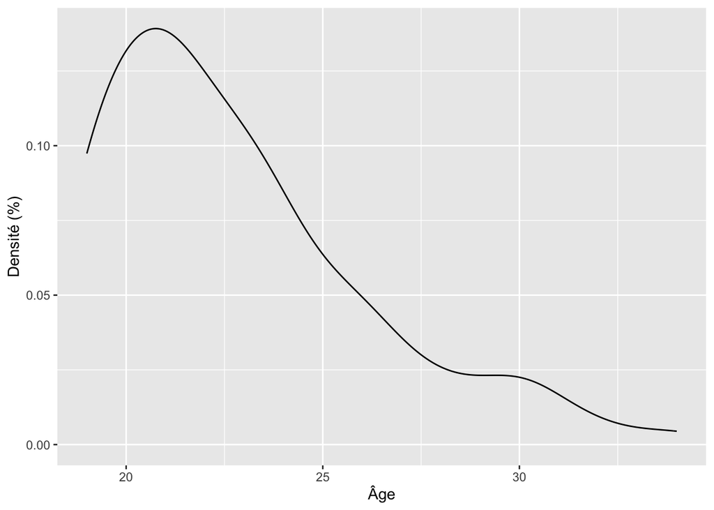

```r
ggplot(df, aes(x = age)) +
  geom_density() +
  labs(x = "Âge", y = "Densité (%)")
```

La quatrième couche (`theme_classic()`) permet simplement de modifier les paramètres d’affichage globaux de votre graphique. Cette couche est utile puisque le thème par défaut de `ggplot2` est honnêtement difficile à regarder. Il existe bien évidemment plusieurs thèmes prédéfinies mais je vous recommande le thème `classic` :

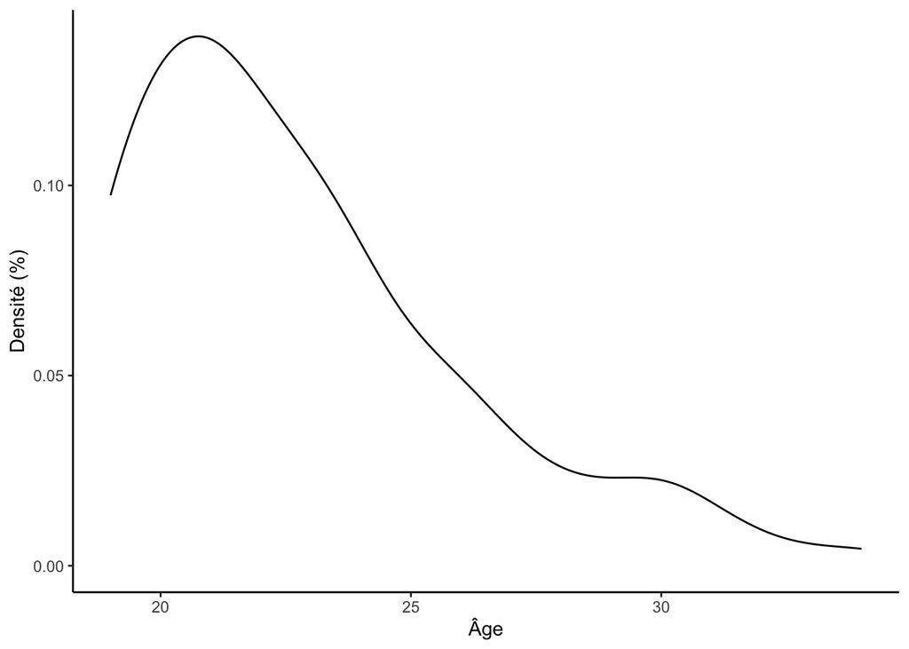

```r
ggplot(df, aes(x = age)) +
  geom_density() +
  labs(x = "Âge", y = "Densité (%)") +
  theme_classic()
```

### 1.1.4 Graphique avancées : superposition

`ggplot2` permet d’être très créatif dans la création de vos graphiques. Un aspect particulièrement intéressant du système de « couches » de ce package est qu’il permet de superposer plusieurs éléments dans un même graphique. Par exemple :

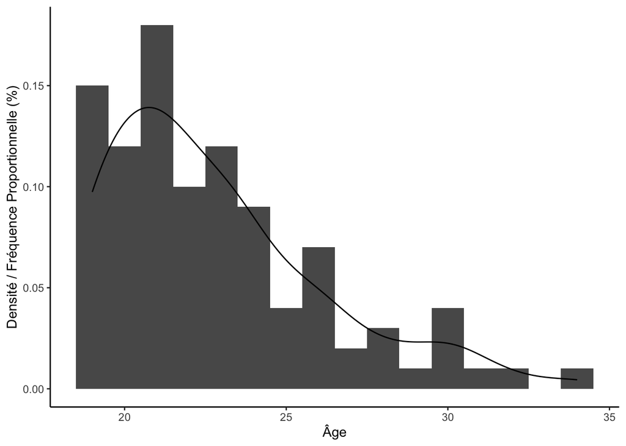

```r
ggplot(df, aes(x = age)) +
  geom_histogram(aes(y = after_stat(density)), binwidth = 1) +
  geom_density() +
  labs(x = "Âge", y = "Densité / Fréquence Proportionnelle (%)") +
  theme_classic()
```

## 1.2 Diagramme à bandes (`geom_bar`)

Le diagramme à bandes permet de montrer la distrubtion d’une variable discrète. L’axe des X représente les valeurs de la variable investiguée et l’axe des Y représente la fréquence des observations pour chacune des valeurs. Ce type de graphique est créé dans `ggplot2` à l’aide de la fonction `geom_bar()`. Voici un exemple :

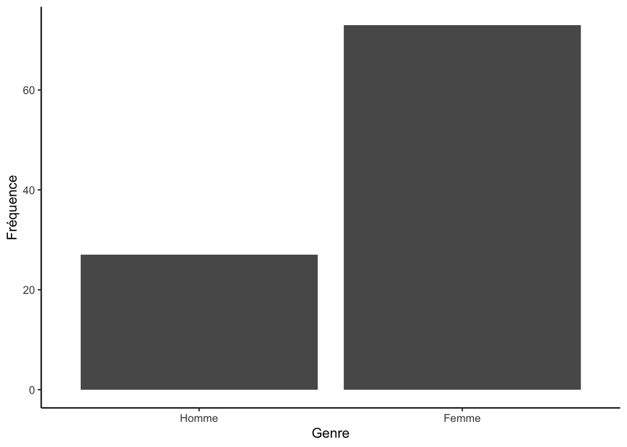

```r
ggplot(df, aes(x = genre)) +
  geom_bar() +
  labs(x = "Genre", y = "Fréquence") +
  theme_classic()
```

## 1.3 Histogramme (`geom_histogram`)

L’histogramme permet de montrer la distribution d’une variable continue. Comme pour le diagramme à bandes, l’axe des X représente les valeurs de la variable investiguée. La seule différence avec le diagramme à bandes est que l’axe des Y d’un histogramme représente la fréquence des observations *pour un intervalle spécifique de l’axe des X*. Ce type de graphique est créé dans `ggplot2` à l’aide de la fonction `geom_histogram()`. Voici un exemple :

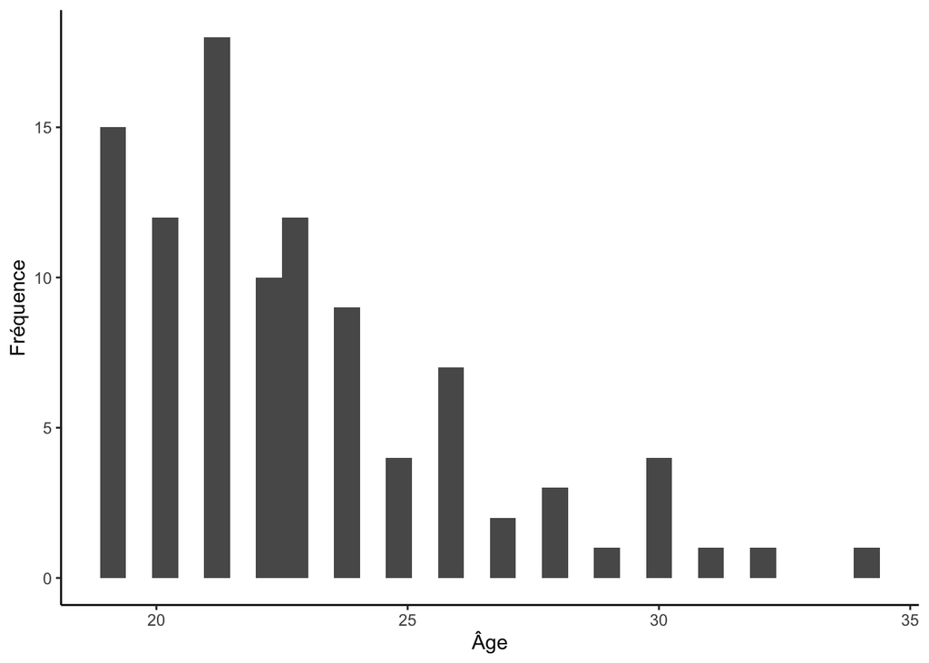

```r
ggplot(df, aes(x = age)) +
  geom_histogram() +
  labs(x = "Âge", y = "Fréquence") +
  theme_classic()
```

Puisque générer un histogramme nécessite la création d’intervalles de valeur sur l’axe des X, la fonction `geom_histogram()` inclue généralement un argument spécifiant soit la largeur des intervalles (`binwidth =`) ou le nombre totale d’intervalles (`bins =`). Par défaut, la fonction `geom_histogram()` défini à 30 le nombre d’intervalles. Toutefois, ce nombre est rarement approprié, ce pourquoi `ggplot2` génère un avertissement si le nombre d’intervalles n’est pas modifié manuellement.

Actuellement, les experts ne s’entendent pas sur la « meilleure » façon de déterminer le nombre d’intervalles dans un histogramme (pour une discussion sur les formules proposées, voir [l’article wikipedia sur les histogrammes](https://en.wikipedia.org/wiki/Histogram#Number_of_bins_and_width)). Ainsi, le choix du nombre ou de la largeur des intervalles vous revient entièrement. À titre de règle générale, essayez d’avoir entre 7 et 20 intervalles pour donner à votre lecteur une idée de la répartition des scores.

Voici un histogramme défini en fonction de la largeur des intervalles :

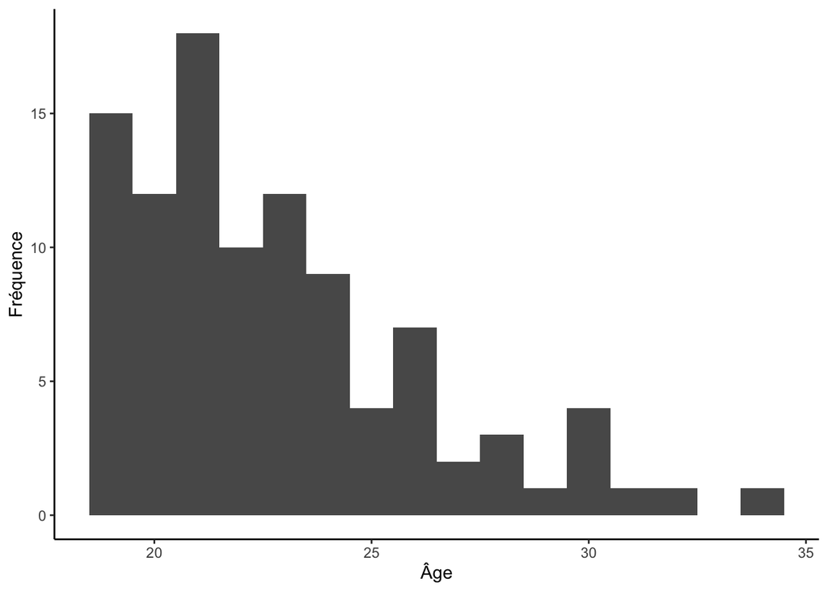

```r
ggplot(df, aes(x = age)) +
  geom_histogram(binwidth = 1) +
  labs(x = "Âge", y = "Fréquence") +
  theme_classic()
```

Voici un autre histogramme définie en fonction du nombre d’intervalles :

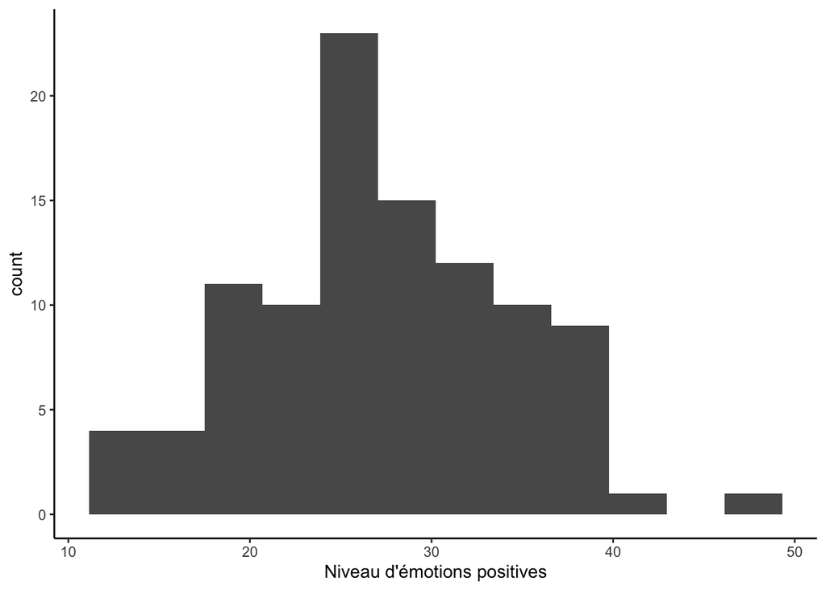

```r
ggplot(df, aes(x = emotionPositive)) +
  geom_histogram(bins = 12) +
  labs(x = "Niveau d'émotions positives", "Fréquence") +
  theme_classic()
```

## 1.4 Diagramme de dispersion (`geom_point`)

Le diagramme de dispersion vous permet de montrer la relation entre deux variables continues. Chaque observations est représentée comme un point dans le graphique. Ce type de graphique est créé dans `ggplot2` à l’aide de la fonction `geom_point()`. Voici un exemple :

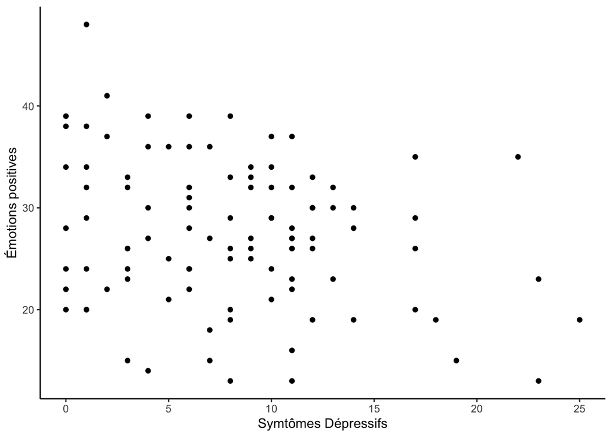

```r
ggplot(df, aes(x = symptomesDepressifs, y = emotionPositive)) +
  geom_point() +
  labs(x = "Symtômes Dépressifs", y = "Émotions positives") +
  theme_classic()
```

## 1.5 Boxplot (`geom_boxplot`)

Le *boxplot* (ou boîte à moustache) vous permet de montrer la relation entre une variable discrète et une variable continue. Notez toutefois que ce graphique peut également être utilisé pour représenter la distribution d’une seule variable continue, même si on privilégie généralement l’histogramme dans ce contexte. Voici un exemple :

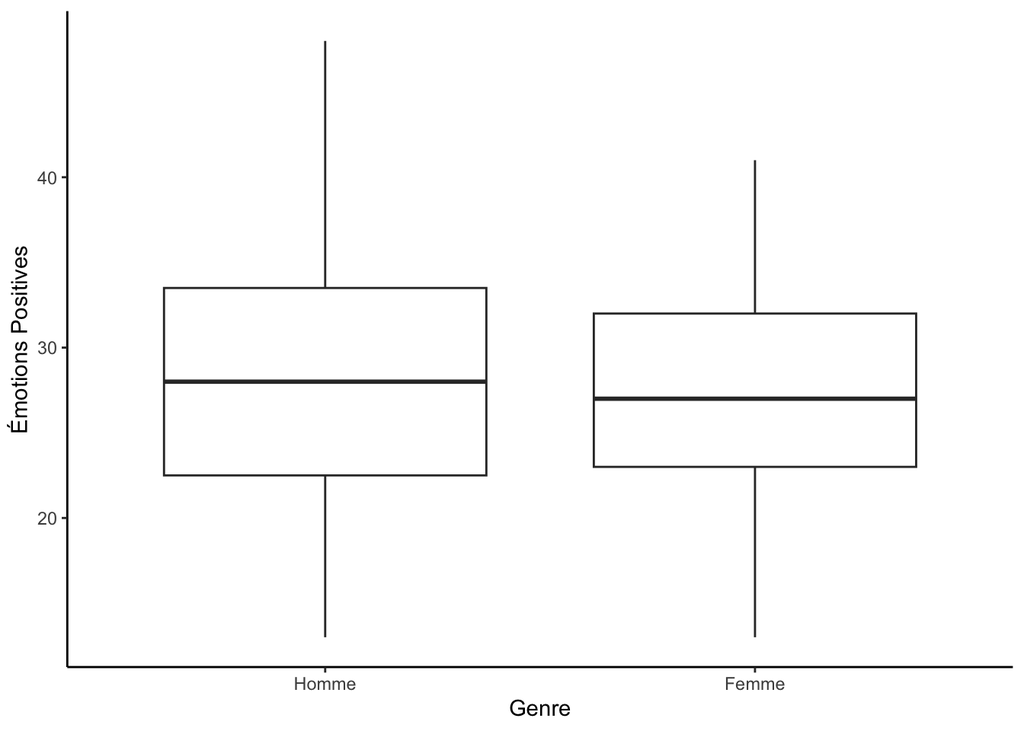

```r
ggplot(df, aes(x = genre, y = emotionPositive)) +
  geom_boxplot() +
  labs(x = "Genre", y = "Émotions Positives") +
  theme_classic()
```

# 2 Ressources supplémentaires

- [Site officiel](https://ggplot2.tidyverse.org/)
- [Cheat sheet `ggplot2`](https://www.maths.usyd.edu.au/u/UG/SM/STAT3022/r/current/Misc/data-visualization-2.1.pdf)